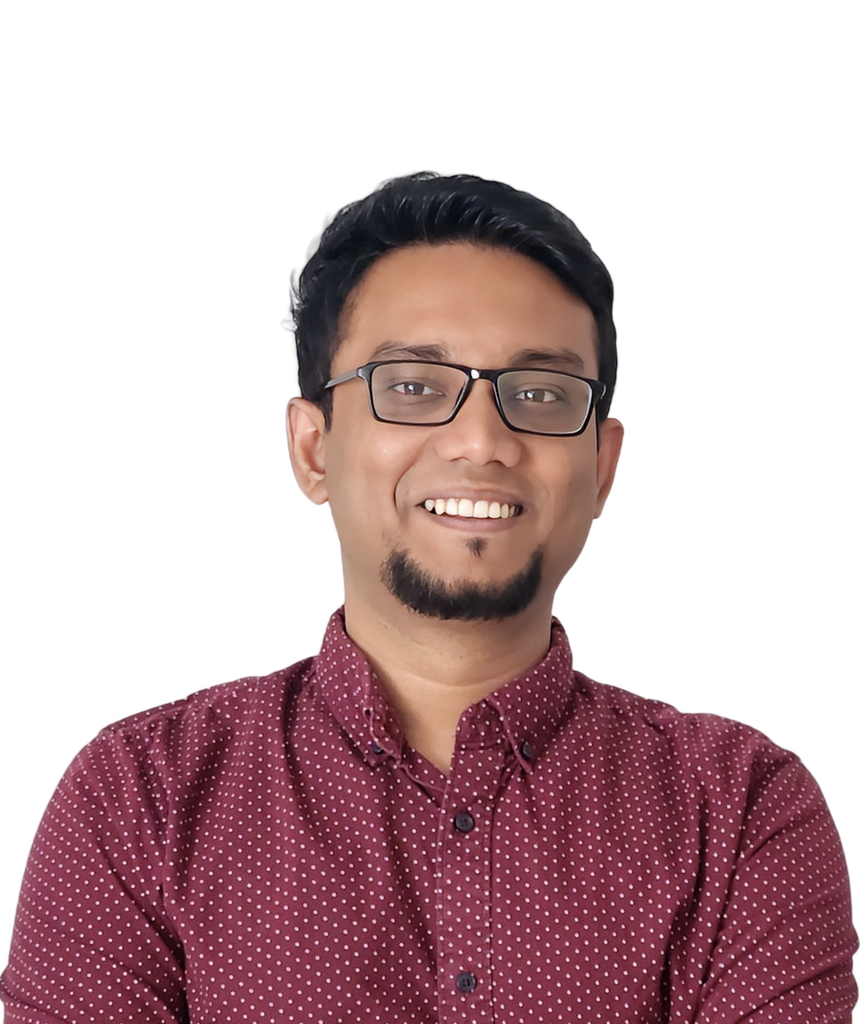

# Toufiq Rahman

[LinkedIn](https://www.linkedin.com/in/tofuiba/) CV [JMP](https://www.dropbox.com/scl/fi/ggskshcy4m582pzm4tsqx/BMI_sep2024.pdf?rlkey=rslmrppi5jffd19vce2f6fc4c&st=ru31v465&dl=0) Email

**Hi, I'm Toufiq.**

I am an applied microeconomist. My research leverages modern econometric tools to address questions relevant to health, education, and labor policies.

I recently completed Ph.D. in Economics from Georgia State University and will be joining Johns Hopkins University Carey Business School as a Postdoc this fall.

Click here to view my CV.

### Research

Do Incentives Shape Teacher Effort? Lessons from a Piece-rate Bonus Program Job Market Paper

with Ian Callen

We study the effects of a novel piece-rate teacher bonus program on student outcomes. We propose a model implying that the piece-rate and the cap generate higher incentives for teachers with relatively lower baseline student number and aptitude. The model further predicts that the bonus program does not effectively incentivize teachers with a high baseline number of students passing the AP exams, since they are likely to automatically qualify for the maximum reward without exerting additional effort...

From Coverage to Consequences: BMI and Health Behaviors after Medicaid Contraction Under Review

Leveraging Tennessee’s 2005 Medicaid contraction, I study the impact of losing public health insurance on body weight and relevant health behaviors. Using Behavioral Risk Factor Surveillance System (BRFSS) data from 1997 to 2010, I estimate comparative case study models with data-driven control groups. The preferred synthetic difference-in-differences estimates suggest that the reform increased Body Mass Index by 0.38 points and the overweight or obesity prevalence (BMI≥25) by ∼4% among Tennessean childless adults...

[PDF](https://www.dropbox.com/scl/fi/ggskshcy4m582pzm4tsqx/BMI_sep2024.pdf?rlkey=rslmrppi5jffd19vce2f6fc4c&st=ru31v465&dl=0)

Removing Barriers to College Credits: Where and for Whom AP Exam Fee Waivers Work

with Cade Lawson

Do policies that broaden educational access also foster success? We study this question in the context of North Carolina’s universal Advanced Placement (AP) exam fee waiver policy, analyzing its effects on the likelihood of exam participation and achieving a passing score (>=3 out of 5). Using administrative data and exploiting within-student variation, we find that fee waivers significantly increased AP exam participation but had no effect on overall pass rate among AP-enrolled students...

Request Draft

#### Select Work in Progress:

- The Effect of Gentrification on College Tuition
- The Contribution of Firms to Voting Behavior (with Michael Luca, Daniel Kreisman, and Jonathan Smith)
- R Package: `propWeights`

### Teaching

**Instructor of Record, Georgia State University**

- ECON 2105: Principles of Macroeconomics (Fall 2024) [Syllabus]
- ECON 8220: Human Resources and Labor Markets (Spring 2025) [Syllabus]

**Graduate Teaching Assistant, Georgia State University**

- ECON 9230: Topics in Advanced Labor Economics (Spring 2025)

View my complete teaching evaluations.